# Experiments with parameter mixing for Adrakey model

Adam Zeiliinger

6/12/2019

## Results from examining mixing and estimation problems with Adrakey model parameters

Below are the results for three “experiments”. First, I set each of the three parameters (alpha, beta, and epsilon) equal to the “true value”, where the true value is the one used by Adrakey et al. to run their simulation in the Suppl. Material. Then I removed monitors on two of the three parameters.

The true values of the parameters are:  
- alpha = 0.08  
- beta = 7e-06  
- epsilon = 5e-05

I ran each experiment with the following MCMC conditions:  
- iterations = 100K  
- burnin = 1000  
- thin = 2  
- nchains = 2  
- RNG seed = 1 (seed set differently for different MCMC chains, but only chain 1 analyzed below)

## Results of experiment monitoring alpha

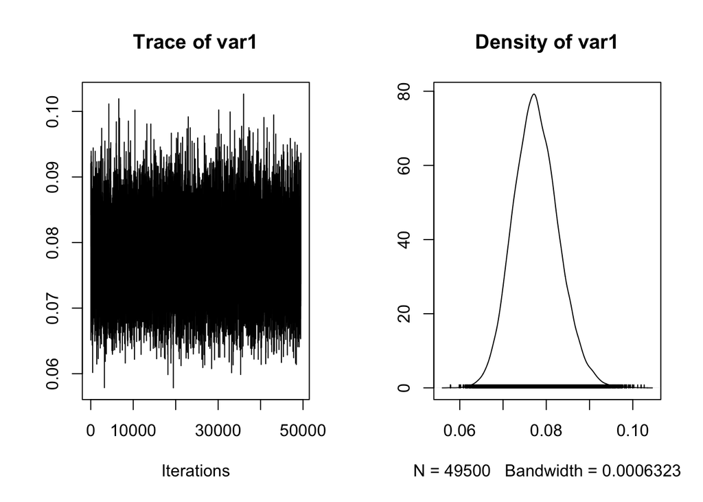

```r
samples <- readRDS("output/raw_mcmc_samples_alpha_test.rds")
samplesAlpha <- samples[[1]]


## Getting just the model parameters
paramcols <- which(attr(samplesAlpha, "dimnames")[[2]] == "alpha")
paramsAlpha <- samplesAlpha[,paramcols]
## Make paramList a list of MCMC samples of just the three parameters
paramAlphaList <- list(paramsAlpha, samples[[2]][,paramcols])

plot(paramsAlpha)
```

```r
## Gelman-Rubin diagnostic
gelman.diag(paramAlphaList)
```

```
## Potential scale reduction factors:
##
##      Point est. Upper C.I.
## [1,]          1          1
```

```r
## Effective sample size
round(cbind(
  niterations = length(paramsAlpha),
  ESS    = effectiveSize(paramsAlpha)
))
```

```
##      niterations   ESS
## var1       49500 20128
```

```r
## Summary of posterior distributions
res <- round(cbind(
  `cilower` = apply(samplesAlpha, 2, function(x) quantile(x, 0.025)),
  `mean`    = apply(samplesAlpha, 2, mean),
  `median`  = apply(samplesAlpha, 2, median),
  `ciupper` = apply(samplesAlpha, 2, function(x) quantile(x, 0.975))
), 8)

tail(res)
```

```
##                     cilower         mean       median      ciupper
## Inf_times[998]  300.6411763 314.57606927 314.89694955 328.99455935
## Inf_times[999]  262.0820600 309.71918012 309.19834097 360.00000000
## Inf_times[1000] 264.6212852 315.81062479 318.48229041 360.00000000
## alpha             0.0679285   0.07763225   0.07742522   0.08839713
## beta              0.0000070   0.00000700   0.00000700   0.00000700
## epsilon           0.0000500   0.00005000   0.00005000   0.00005000
```

## Results of experiments monitoring beta

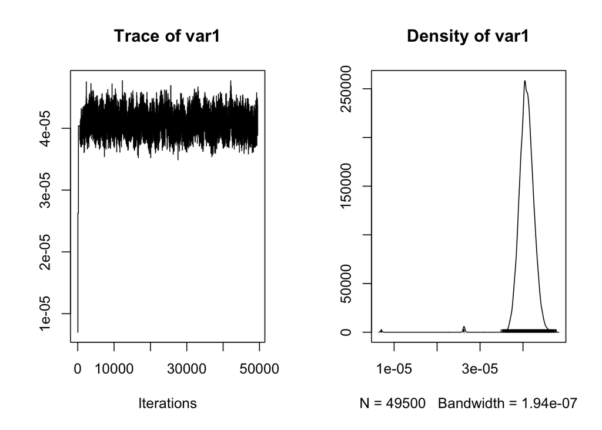

```r
samples <- readRDS("output/raw_mcmc_samples_beta_test.rds")
samplesBeta <- samples[[1]]


## Getting just the model parameters
paramcols <- which(attr(samplesBeta, "dimnames")[[2]] == "beta")
paramsBeta <- samplesBeta[,paramcols]
## Make paramList a list of MCMC samples of just the three parameters
paramBetaList <- list(paramsBeta, samples[[2]][,paramcols])

plot(paramsBeta)
```

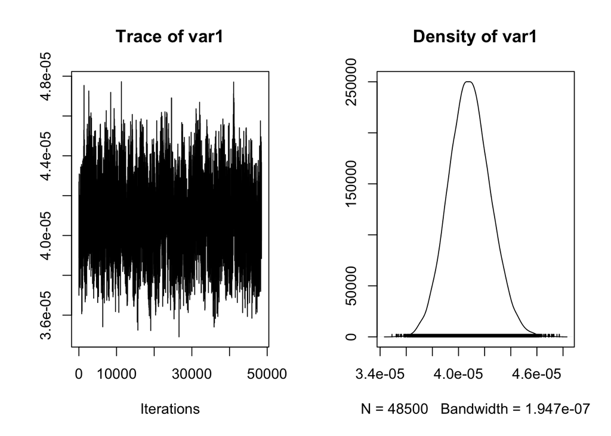

```r
## Burnin apparently not long enough for beta
## Try plotting again after removing an additional 1000 iterations
paramsBeta <- paramsBeta[1001:length(paramsBeta)]
plot(as.mcmc(paramsBeta))
```

```r
## Gelman-Rubin diagnostic
gelman.diag(paramBetaList)
```

```
## Potential scale reduction factors:
##
##      Point est. Upper C.I.
## [1,]       1.01       1.04
```

```r
## Effective sample size
round(cbind(
  niterations = length(paramsBeta),
  ESS    = effectiveSize(paramsBeta)
))
```

```
##      niterations ESS
## var1       48500 469
```

```r
## Summary of posterior distributions
res <- round(cbind(
  `cilower` = apply(samplesBeta, 2, function(x) quantile(x, 0.025)),
  `mean`    = apply(samplesBeta, 2, mean),
  `median`  = apply(samplesBeta, 2, median),
  `ciupper` = apply(samplesBeta, 2, function(x) quantile(x, 0.975))
), 8)

tail(res)
```

```
##                      cilower         mean       median      ciupper
## Inf_times[998]  300.50833468 312.80337014 312.05942622 328.58213061
## Inf_times[999]  263.80365883 310.20294408 308.24341820 356.33167358
## Inf_times[1000] 279.39137606 325.07692639 326.27448411 354.80654241
## alpha             0.08000000   0.08000000   0.08000000   0.08000000
## beta              0.00003775   0.00004077   0.00004079   0.00004405
## epsilon           0.00005000   0.00005000   0.00005000   0.00005000
```

## Results of experiments monitoring epsilon

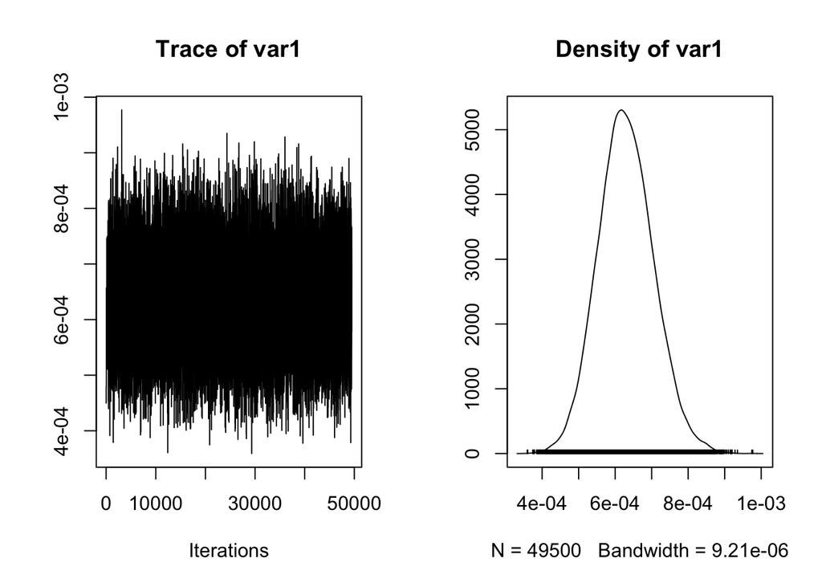

```r
samples <- readRDS("output/raw_mcmc_samples_epsilon_test.rds")
samplesEpsilon <- samples[[1]]


## Getting just the model parameters
paramcols <- which(attr(samplesEpsilon, "dimnames")[[2]] == "epsilon")
paramsEpsilon <- samplesEpsilon[,paramcols]
## Make paramList a list of MCMC samples of just the three parameters
paramEpsilonList <- list(paramsEpsilon, samples[[2]][,paramcols])

plot(paramsEpsilon)
```

```r
## Gelman-Rubin diagnostic
gelman.diag(paramEpsilonList)
```

```
## Potential scale reduction factors:
##
##      Point est. Upper C.I.
## [1,]          1          1
```

```r
## Effective sample size
round(cbind(
  niterations = length(paramsEpsilon),
  ESS    = effectiveSize(paramsEpsilon)
))
```

```
##      niterations   ESS
## var1       49500 17460
```

```r
## Summary of posterior distributions
res <- round(cbind(
  `cilower` = apply(samplesEpsilon, 2, function(x) quantile(x, 0.025)),
  `mean`    = apply(samplesEpsilon, 2, mean),
  `median`  = apply(samplesEpsilon, 2, median),
  `ciupper` = apply(samplesEpsilon, 2, function(x) quantile(x, 0.975))
), 8)

tail(res)
```

```
##                      cilower         mean       median      ciupper
## Inf_times[998]  301.03132562 314.78013527 314.90764906 329.01497023
## Inf_times[999]  262.05169299 310.67016450 310.06707420 358.81036272
## Inf_times[1000] 265.52040895 315.64946211 320.06843913 358.64897830
## alpha             0.08000000   0.08000000   0.08000000   0.08000000
## beta              0.00000700   0.00000700   0.00000700   0.00000700
## epsilon           0.00048679   0.00063014   0.00062769   0.00078499
```

## Results from mixing experiments employing multiple configurations

For these runs, I set up two MCMC configurations:  
- MCMCconf: where samplers for all three parameters (alpha, beta, epsilon) were removed, so only infection times were sampled  
- MCMCconf2: where samplers were removed for 2 out of 3 parameters; here infection times and one parameter (either beta or epsilon) were sampled

I ran the MCMCs with these configurations in serial. I specified 5,000 iterations for the first run (for MCMCconf) and 100,000 iterations for the second run (for MCMCconf2). Otherwise, the specifications for the MCMCs were identical. I did not set a RNG seed prior to either MCMC run.

```r
MCMCconf <- configureMCMC(Rmodel, nodes = c("alpha", "beta", "epsilon"))
MCMCconf$addSampler(type = 'sampler_infection_quiet',
                    target = 'Inf_indices',
                    control = list(
                      time_intervals = Y,
                      Inf_times_node = 'Inf_times',
                      Inf_indices_node = 'Inf_indices',
                      numInfections_node = 'numInfections',
                      latent_period_node = 'latent_period',
                      Tmax_node = 'Tmax'
                    ))
MCMCconf$addMonitors('Inf_times')
MCMCconf$removeSamplers(c('alpha', 'beta', 'epsilon'))
MCMC <- buildMCMC(MCMCconf)
MCMCconf$printSamplers()



MCMCconf2 <- configureMCMC(Rmodel, nodes = c("alpha", "beta", "epsilon"))
MCMCconf2$addSampler(type = 'sampler_infection_quiet',
                    target = 'Inf_indices',
                    control = list(
                      time_intervals = Y,
                      Inf_times_node = 'Inf_times',
                      Inf_indices_node = 'Inf_indices',
                      numInfections_node = 'numInfections',
                      latent_period_node = 'latent_period',
                      Tmax_node = 'Tmax'
                    ))
MCMCconf2$addMonitors('Inf_times')
MCMCconf2$removeSamplers(c('alpha', 'beta'))
MCMC2 <- buildMCMC(MCMCconf2)
MCMCconf2$printSamplers()

## Compile MCMC for running in C++
Cmcmc <- compileNimble(MCMC, MCMC2, project = Rmodel, resetFunctions = TRUE)


####################################################################################################
#### Multiple MCMC run on Adrakey simulated data

nburnin <- 1
thin <- 2
nchains <- 1

samples <- runMCMC(Cmcmc$MCMC, niter = 5000, nburnin = nburnin, thin = thin,
                   nchains = nchains, samplesAsCodaMCMC = TRUE)
samples2 <- runMCMC(Cmcmc$MCMC2, niter = 100000, nburnin = nburnin, thin = thin,
                    nchains = nchains, samplesAsCodaMCMC = TRUE)
```

## Results of the multi-configurations experiments:

### Epsilon sampled; examining only the posterior of the 2nd MCMC run (samples2), where epsilon was sampled along with infection times

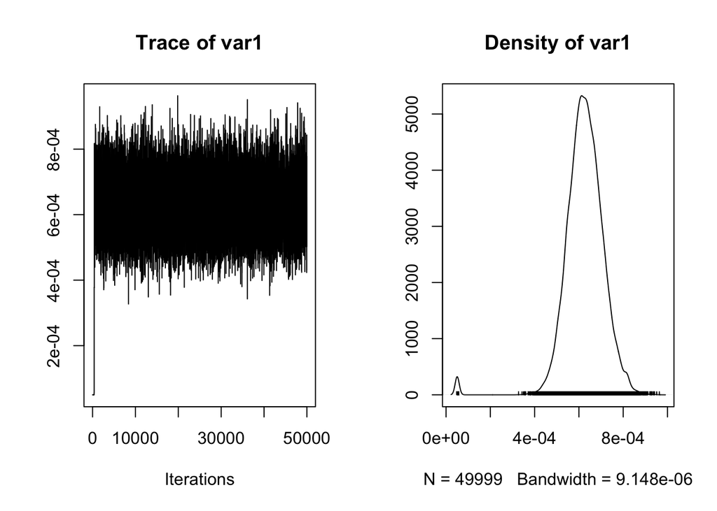

```r
samples <- readRDS("output/raw_mcmc_samples_multi-conf_epsilon_test_in_serial.rds")
samplesMCepsilon <- samples[[2]]


## Getting just the model parameters
paramcols <- which(attr(samplesMCepsilon, "dimnames")[[2]] == "epsilon")
paramsEpsilon <- samplesMCepsilon[,paramcols]

plot(paramsEpsilon)
```

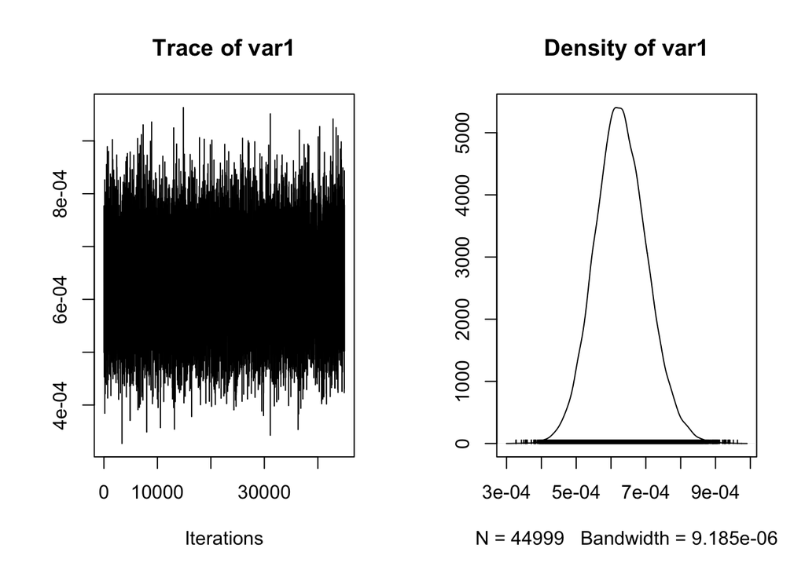

```r
## Apply a burnin and plot again
paramsEpsilon <- paramsEpsilon[5001:length(paramsEpsilon)]
plot(as.mcmc(paramsEpsilon))
```

```r
## Effective sample size
round(cbind(
  niterations = length(paramsEpsilon),
  ESS    = effectiveSize(paramsEpsilon)
))
```

```
##      niterations   ESS
## var1       44999 19018
```

```r
## Summary of posterior distributions
res <- round(cbind(
  `cilower` = apply(samplesMCepsilon, 2, function(x) quantile(x, 0.025)),
  `mean`    = apply(samplesMCepsilon, 2, mean),
  `median`  = apply(samplesMCepsilon, 2, median),
  `ciupper` = apply(samplesMCepsilon, 2, function(x) quantile(x, 0.975))
), 8)

tail(res)
```

```
##                      cilower         mean       median      ciupper
## Inf_times[998]  300.75040416 315.30892481 315.80181128 329.19403626
## Inf_times[999]  262.11534172 310.02287261 311.12406185 358.48868118
## Inf_times[1000] 264.40700653 310.82820101 312.01874673 360.00000000
## alpha             0.08000000   0.08000000   0.08000000   0.08000000
## beta              0.00000700   0.00000700   0.00000700   0.00000700
## epsilon           0.00047528   0.00062492   0.00062648   0.00078429
```

## Results of the multi-configurations experiments:

### Beta sampled; examining only the posterior of the 2nd MCMC run (samples2), where beta was sampled along with infection times

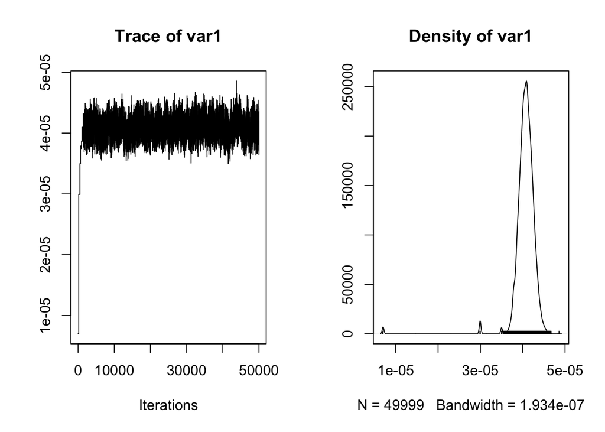

```r
samples <- readRDS("output/raw_mcmc_samples_multi-conf_beta_test_in_serial.rds")
samplesMCbeta <- samples[[2]]


## Getting just the model parameters
paramcols <- which(attr(samplesMCbeta, "dimnames")[[2]] == "beta")
paramsBeta <- samplesMCbeta[,paramcols]

plot(paramsBeta)
```

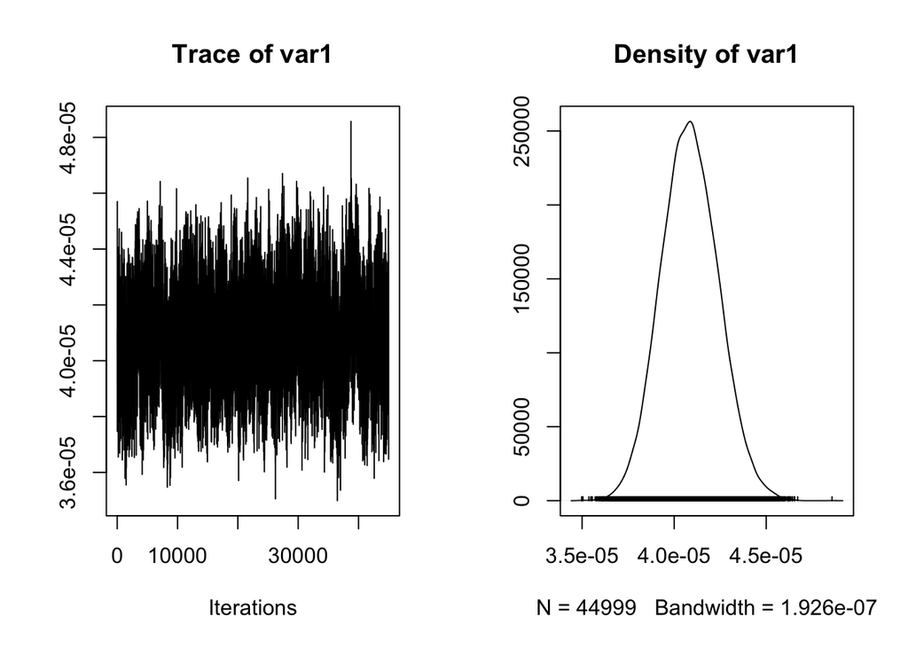

```r
## Apply an additional burnin and plot again
paramsBeta <- paramsBeta[5001:length(paramsBeta)]
plot(as.mcmc(paramsBeta))
```

```r
## Effective sample size
round(cbind(
  niterations = length(paramsBeta),
  ESS    = effectiveSize(paramsBeta)
))
```

```
##      niterations ESS
## var1       44999 595
```

```r
## Summary of posterior distributions
res <- round(cbind(
  `cilower` = apply(samplesMCbeta, 2, function(x) quantile(x, 0.025)),
  `mean`    = apply(samplesMCbeta, 2, mean),
  `median`  = apply(samplesMCbeta, 2, median),
  `ciupper` = apply(samplesMCbeta, 2, function(x) quantile(x, 0.975))
), 8)

tail(res)
```

```
##                      cilower         mean       median      ciupper
## Inf_times[998]  300.66097282 313.52783514 312.69690451 328.43713658
## Inf_times[999]  261.16713729 308.51408955 308.72635175 352.79020063
## Inf_times[1000] 282.35117173 323.29912600 325.45127316 354.95541118
## alpha             0.08000000   0.08000000   0.08000000   0.08000000
## beta              0.00003746   0.00004062   0.00004077   0.00004393
## epsilon           0.00005000   0.00005000   0.00005000   0.00005000
```

#### Summary

In summary, the results of the multi-configuration experiments were equivalent to the first set of experiments. The Effective Sample Size and posterior distributions were unaffected after initializing the sampling of infection times with the first MCMC run.

## Results of experiments from 2019-09-12

The following experiments were run with the following MCMC conditions:  
- iterations = 40K  
- burnin = 1000  
- thin = 1  
- nchains = 1  
- RNG seed = 1

#### Results from experiment with Tmax = 460

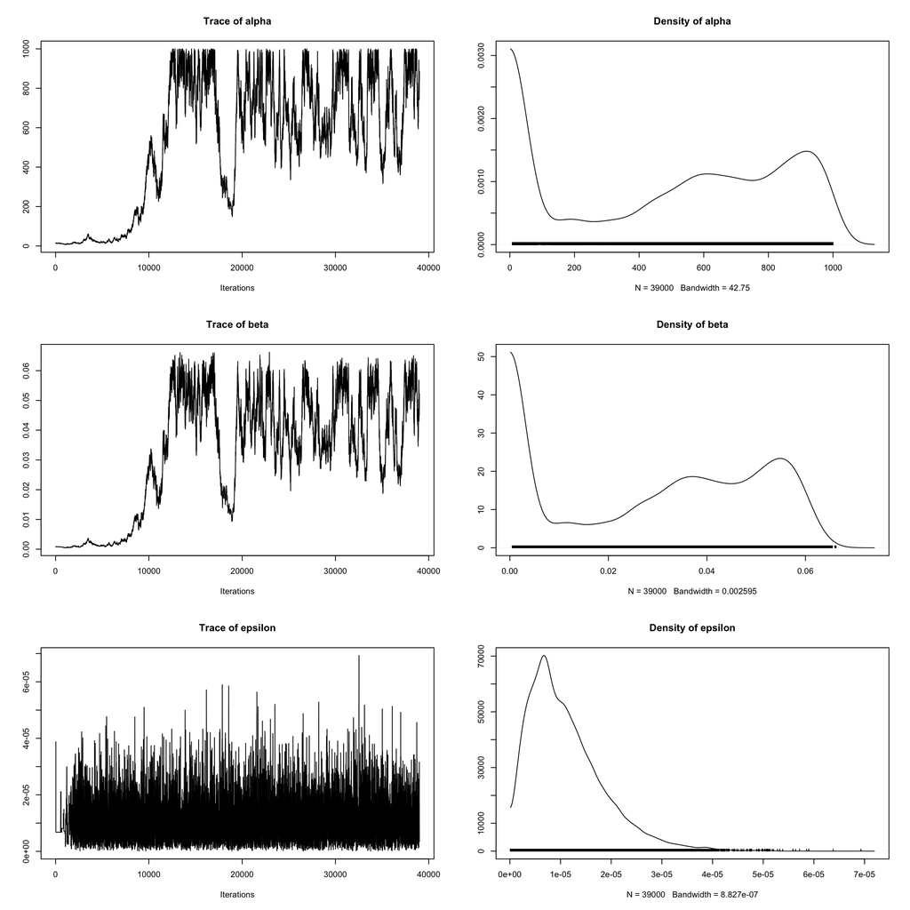

```r
samplesTest <- readRDS("output/raw_mcmc_samples_test_2019-09-12.rds")

## Getting just the model parameters
paramcols <- which(attr(samplesTest, "dimnames")[[2]] == "alpha" | attr(samplesTest, "dimnames")[[2]] == "beta" | attr(samplesTest, "dimnames")[[2]] == "epsilon")
## Need to remove an additional burnin
paramsTest <- as.mcmc(samplesTest[,paramcols])

plot(paramsTest)
```

```r
## Effective sample size
round(cbind(
  niterations = nrow(paramsTest),
  ESS    = effectiveSize(paramsTest)
))
```

```
##         niterations  ESS
## alpha         39000   12
## beta          39000   13
## epsilon       39000 4997
```

```r
## Summary of posterior distributions
res <- round(cbind(
  `cilower` = apply(samplesTest, 2, function(x) quantile(x, 0.025)),
  `mean`    = apply(samplesTest, 2, mean),
  `median`  = apply(samplesTest, 2, median),
  `ciupper` = apply(samplesTest, 2, function(x) quantile(x, 0.975))
), 8)

tail(res)
```

```
##                      cilower         mean       median      ciupper
## Inf_times[998]  300.64643391 316.74616620 317.59664517 328.85174726
## Inf_times[999]  362.17132620 404.83381947 405.48006894 454.30001574
## Inf_times[1000] 360.84707052 402.49581009 400.16706788 455.84092540
## alpha            11.33219637 534.77260009 600.16978061 983.78876846
## beta              0.00069623   0.03235034   0.03620073   0.06040907
## epsilon           0.00000153   0.00001117   0.00000961   0.00002987
```

#### Summary

Burn-in was not nearly long enough, as can be seen by the trace plots and large 95% CI. Estimates of alpha and beta are still very large but epsilon is now underestimated.

#### Results from initializing P = 0 in dDiseaseSpread() and setting Tmax = 460

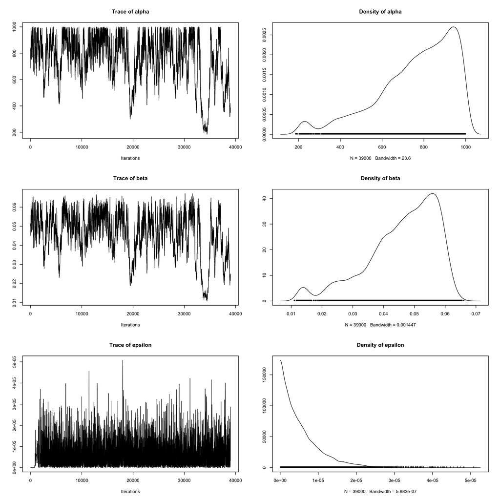

```r
samplesTest2 <- readRDS("output/raw_mcmc_samples_test_2_2019-09-12.rds")

## Getting just the model parameters
paramcols <- which(attr(samplesTest2, "dimnames")[[2]] == "alpha" | attr(samplesTest2, "dimnames")[[2]] == "beta" | attr(samplesTest2, "dimnames")[[2]] == "epsilon")
paramsTest2 <- as.mcmc(samplesTest2[,paramcols])

plot(paramsTest2)
```

```r
## Effective sample size
round(cbind(
  niterations = nrow(paramsTest2),
  ESS    = effectiveSize(paramsTest2)
))
```

```
##         niterations  ESS
## alpha         39000   65
## beta          39000   63
## epsilon       39000 2501
```

```r
## Summary of posterior distributions
res <- round(cbind(
  `cilower` = apply(samplesTest2, 2, function(x) quantile(x, 0.025)),
  `mean`    = apply(samplesTest2, 2, mean),
  `median`  = apply(samplesTest2, 2, median),
  `ciupper` = apply(samplesTest2, 2, function(x) quantile(x, 0.975))
), 8)

tail(res)
```

```
##                      cilower         mean       median      ciupper
## Inf_times[998]  301.13150269 316.37554529 316.97878189 329.10396873
## Inf_times[999]  360.96238998 404.38651689 402.92510678 450.09678804
## Inf_times[1000] 364.67187301 407.08278850 403.17651889 458.02563025
## alpha           278.60456722 760.03237556 797.82226252 991.56294269
## beta              0.01638512   0.04606869   0.04828477   0.06118784
## epsilon           0.00000013   0.00000564   0.00000399   0.00002060
```

#### Summary

Making the (apparently) small change of setting P <- 0 instead of P <- log(epsilon) changed the mixing of the MCMC quite a bit based on the trace and density plots. The parameter estimates are roughly similar from the 1st and 2nd tests: estimates of alpha and beta are much larger than the true values (by several orders of magnitude), whereas epsilon is underestimated (by less than one order of magnitude).